# “Cancer: The Rising Mortality Rate in Relation to Urbanization and Aging Population Around the World”

Tam Nguyen, Ting Huang and Chris McConnell

[link to git collab](https://github.com/thuang111/Ting_Tam_Chris_final_project)

# Introduction

## Introduction and Background

Cancer is one of the leading causes of death in the world with millions of people dying every year to the disease. Cancer forms when cells in the body begin to grow and multiply uncontrollably generally due to changes in genes or damage to DNA. This can make the disease extremely difficult to treat with most treatments being invasive or physically taxing with no guarantee of success. People of any age, sex, and race can get cancer though it typically occurs in older people. We also wanted to analyze other factors that can contribute to higher rates of cancer mortality. One aspect that came to mind was urban versus rural populations, as we have seen reports and data that say people in urban areas are more likely to die of cancer than those in rural areas.  
We are interested in seeing patterns in cancer deaths around the world in order to find out which cancers are the most lethal and where the most people are dying from cancer. We believe this gave us insight into why cancer deaths appear to be rising and some potential reasons for the deaths and the changes of death counts over time. Along with this, cancer is something that everyone is impacted by at some point in their life. Whether it be a grandparent, parent, or close friend, in many ways cancer is inescapable in the modern world. We may be able to look through this data and find new connections that we have not considered before.

## Research Questions

Q1: Which countries have the highest death rates by cancer per 1,000 people (total) throughout 2000 to 2017?  
Q2: Do urban areas have higher rates of cancer, and if so what cancers are more common in these urban areas?  
Q3: Is the age of a country’s population also a predictor of cancer deaths?

# Data Sources and Manipulation

**cancer**: We chose this particular data set because it has a list of many different cancer types and corresponding records of how many people died of each specific type, in each year, for numerous countries. Therefore, we felt it would give more dimensions to the content of our project. To collect it, we used R to import the data from Kaggle.We then wanted to change the code a bit so we could use it how we wanted to. We reduced the amount of columns by creating the “Type of cancer” variable which each had the value of the specific type of cancer. In the original data, there was a column for each type of cancer death that had an associated number.

Working with this dataset only is insufficient for us to pursue aforementioned research questions. Therefore, we decided to load more data sets, which are listed below:  
**world_pop_new**: This data set contains population statistics including total population and total growth rate as well as urban population and urban growth rate. We also did some data manipulation to get the total death count by country, regardless of cancer type. This came included with RStudio

**world**: The data, containing shapefiles of 241 countries and regions in the world, will be used later to show cancer death rates world wide

```
## [1] "sf"         "data.frame"
```

**pop_age**: data containing the percentage of people over 65 over total population of 50 countries

**cancer_pop**: In order to facilitate further analysis, we combined both our cancer data and population data to get cancer deaths per capita, which helps us immensely in seeing countries with higher rates of cancer than others. Before this, any time we wanted to check which countries had the highest cancer deaths it would only show up countries with large populations such as China or the USA.

# Analysis

To start off, we wanted to paint the general picture of what cancer types are the most common on a global scale and non ational scale of a random country. We decided to choose the US since this is where we currently are.

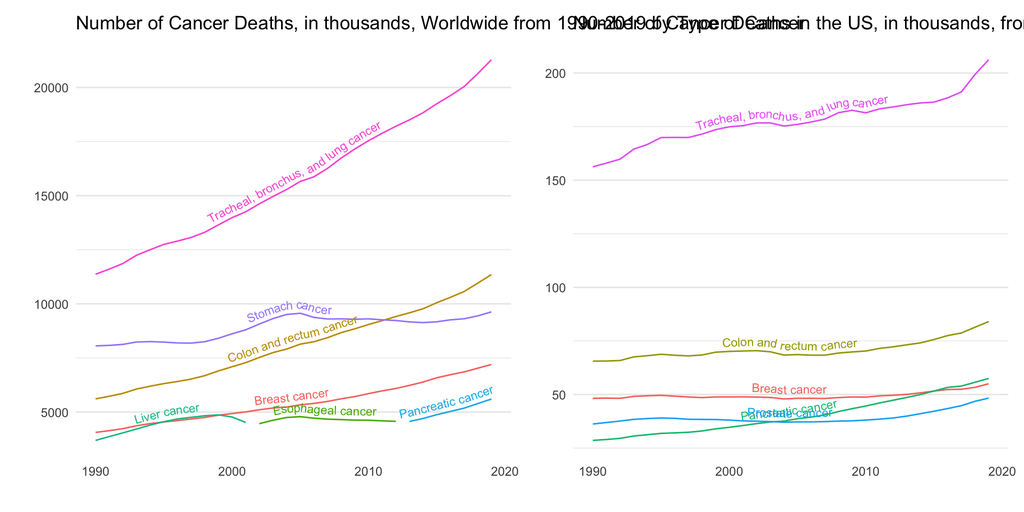

This graph is what first brought to our attention the fact that trachael, bronchus, and lung cancer was the most common cancer to die from in the world. It was solidly the most common cancer by a large margin, with the next most common (colon and rectum cancer) only having around half of the deaths of lung cancers. Another notable part of this graph is that there are multiple types of cancer that had radical increases. Both lung cancers, colon and rectum cancers, and breast cancers almost doubled in mortalities from 1990 to 2019. This shows the importance of noting the types of cancers that are becoming more common, as they oftentimes have different treatments available compared to other forms of cancer. While it is easy to say that rates of cancer mortality are rising, it is important to see which kinds of cancer they are in order to identify the roots and whether this rise is correlated with increases in population or represents an actual increase in lethality.  
Curious to see which countries in the world have high cancer deaths per 1,000 people and to observe if those countries changed throughout the years, we specifically picked and plotted this information in 3 distinct year - 2000, 2008 and 2017, which correspond to the beginning, middle and the end of our time frame respectively.

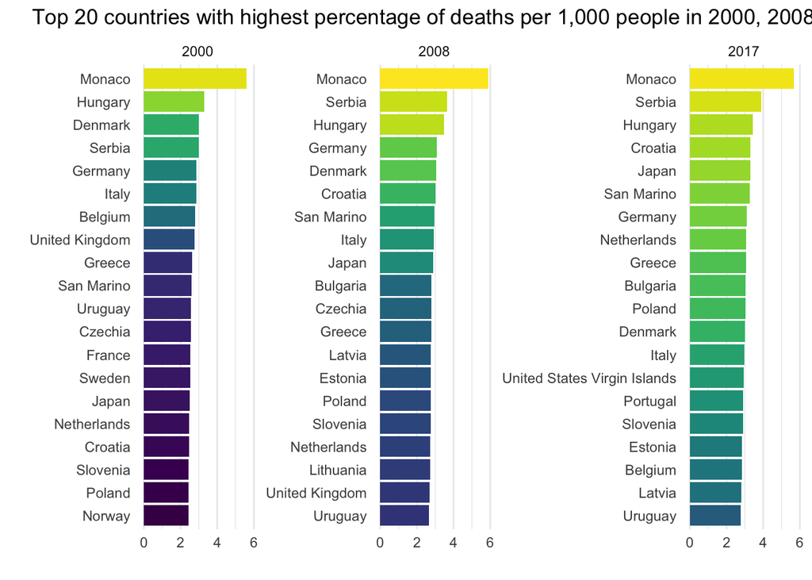

```
## 203 codes from your data successfully matched countries in the map
## 64 codes from your data failed to match with a country code in the map
## 40 codes from the map weren't represented in your data
```

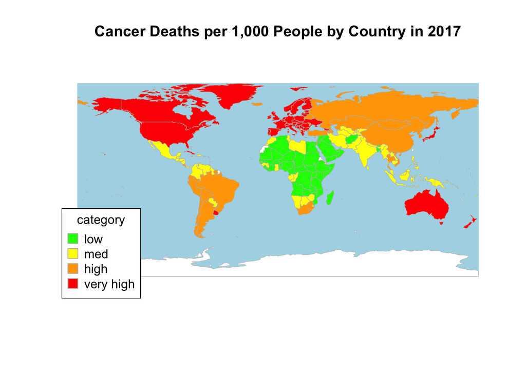

From the map above, we can see that in 2017 most of the Western countries experienced the highest cancer death rates. Although not clearly shown here, we have learned from before that out of the Western world, the Europe is the most heavily affected.  
Furthermore, we dive deeper into the issue by plotting to see which specific types of cancer caused the most deaths in the top 6 countries.

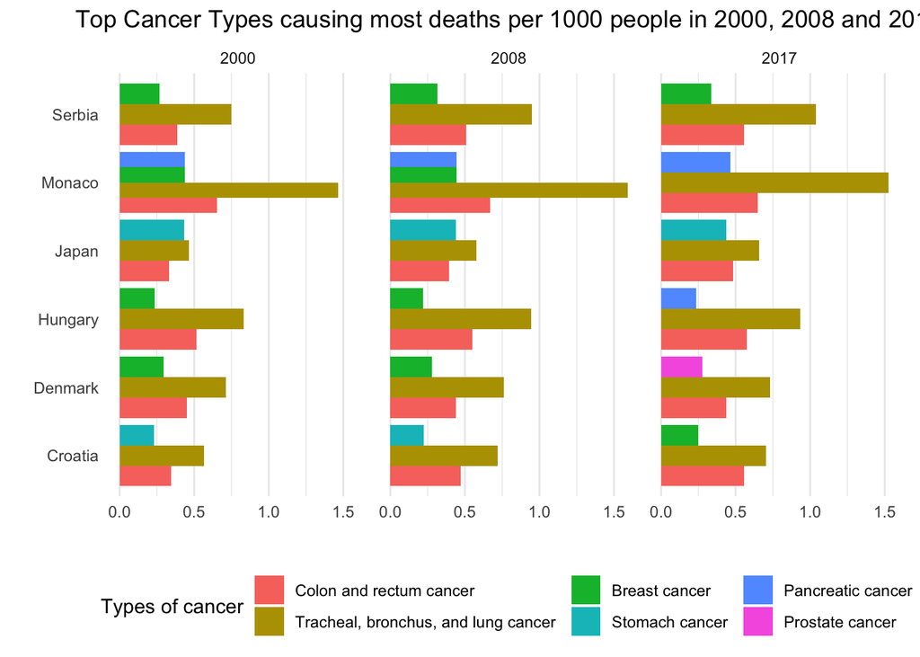

This graph is where we can see the correlations of the three most common causes of cancer deaths in six of the countries with the most cancer deaths per capita. We can see that for every country over the three years analyzed, tracheal, bronchus, and lung cancer remains the most common fatal cancer type. Interestingly, Monaco has some of the highest gaps between lung cancers and other forms of cancer. It is also important looking at this graph to think about which types of cancers are fatal compared to others. For example, rectal cancer is seen as one of the most deadly cancers as it almost solely affects the population over 50, a group more prone to dying from cancer in comparison to those younger than 50.

## Urbanization

So can we determine whether or not there is a positive correlation between urban growth rate and cancer death rate? If so, how?

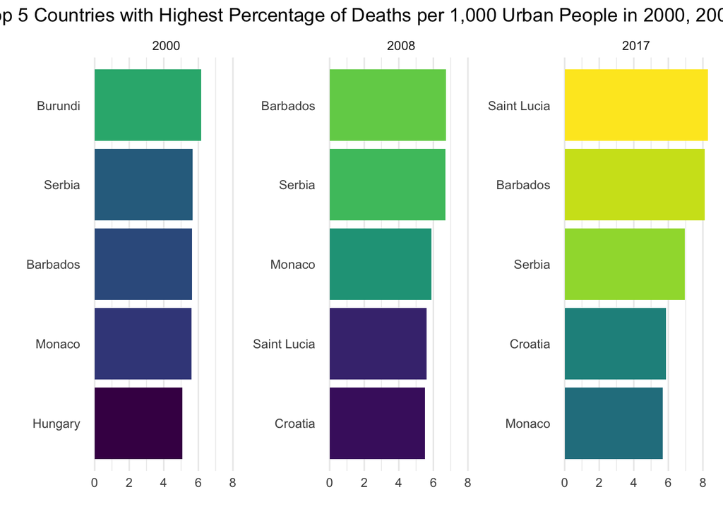

This graph shows the value in breaking down the types of cancer as well as the countries. When compared to the initial graph of countries with the highest rates of cancer deaths per 1000 people, there are many of the same countries bar three. Burundi only appears once at #1, implying that there was a local epidemic that was solved by 2008. For Barbados and Saint Lucia, we can see in fig3b that these two countries weren’t as affected by tracheal, bronchial, and lung cancer; rather they each had a specific type of cancer that seemed to be a local problem for the country. We were unable to learn much about what we wanted to with this graph, but it serves as a starting point for a more broad exploration into the analysis of more local groups of countries and unique problems they may face when it comes to cancer deaths.

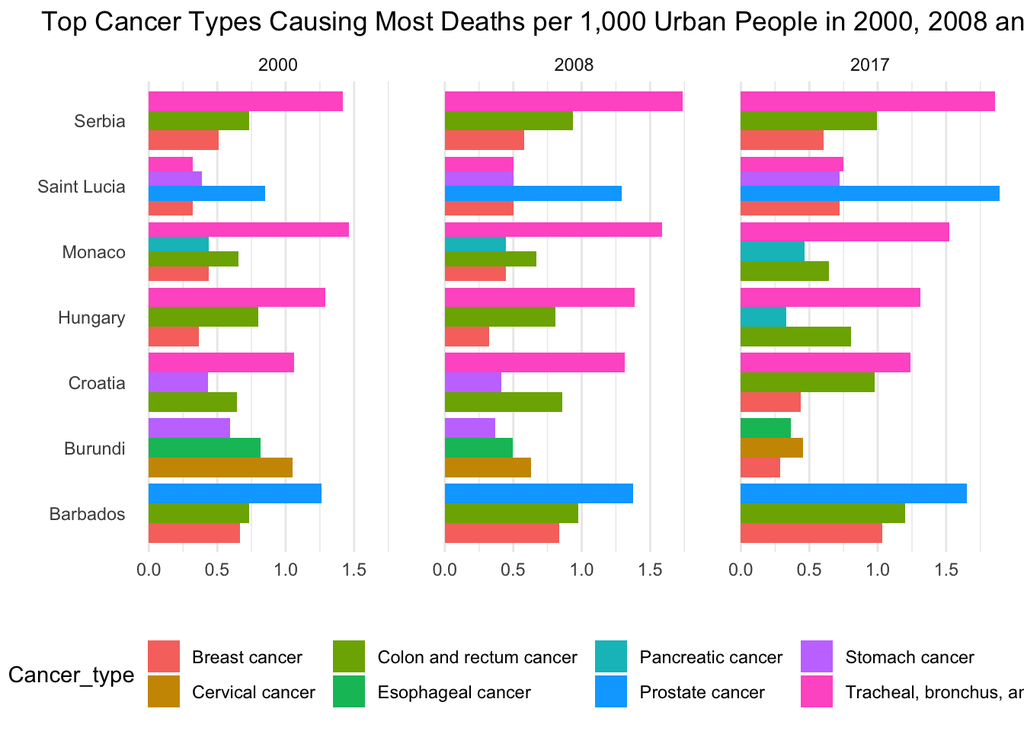

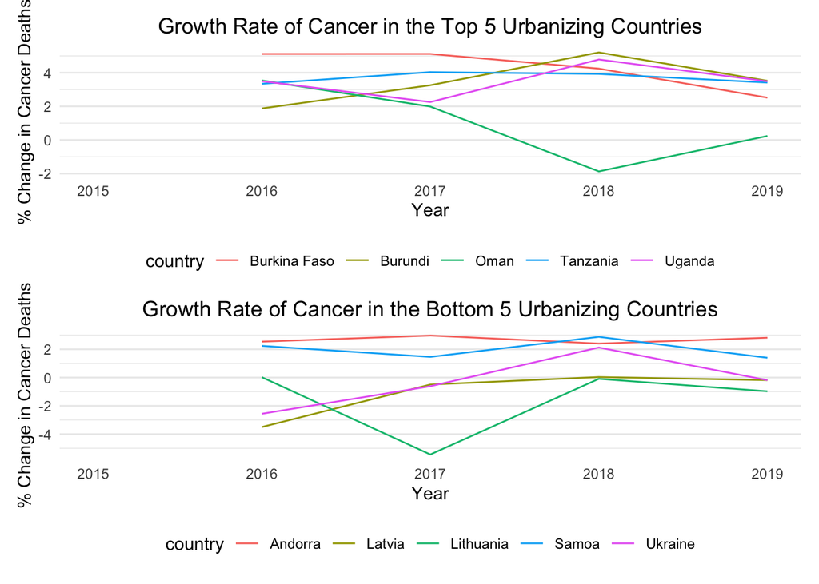

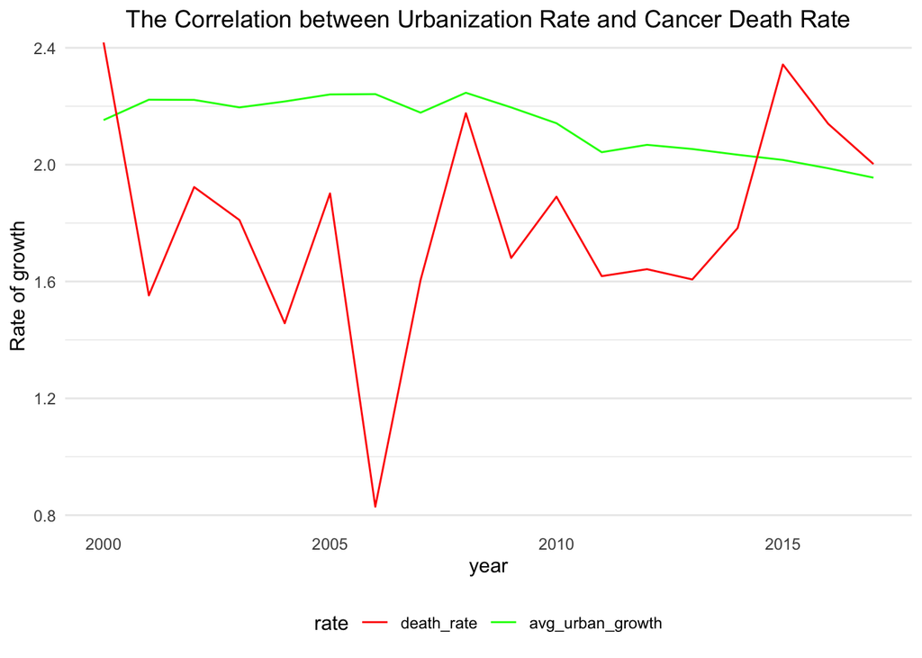

Unfortunately, the world eye view says otherwise: there is not enough visual evidence to conclude that urban population growth rate positively associates with cancer death rate. This conclusion resonates with that of a scholarly paper addressing a similar issue, which one can access here [Urban sprawl, obesity, and cancer mortality in the United States: cross-sectional analysis and methodological challenges - PMC](https://www.ncbi.nlm.nih.gov/pmc/articles/PMC3898779/)

Despite the unsatisfying finding, if we continue to take the characteristics of an urban society into consideration, we might find a relationship between urban growth and a cancer type suspected to associate with modernization. As a result, we choose to inspect lung cancer.

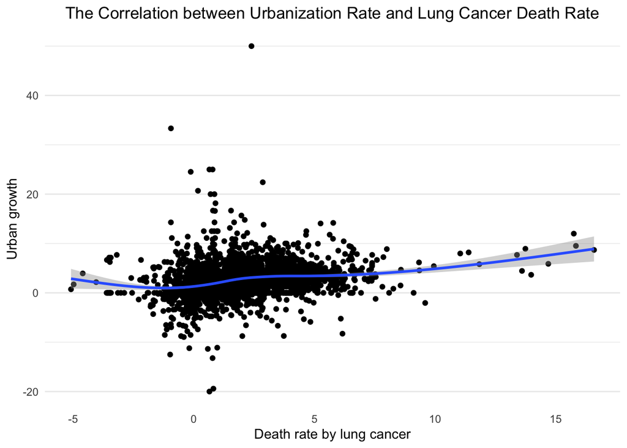

Indeed, even though there is not enough evidence to prove that total cancer death rate positively correlates with urban population growth, visually, lung cancer does have a positive relationship with urban growth rate. Intuitively, this makes sense because as the air quality in urban areas gets worse by the year, the risk of damaging cells in the lungs becomes greater for urban residents. Statistically, this also proves to be true:

```
##                          Estimate Std. Error  t value      Pr(>|t|)
## (Intercept)             1.7152033 0.07700844 22.27293 1.112890e-102
## urban_population_growth 0.4078296 0.02658896 15.33830  2.169136e-51
```

What we can learn from this is that it might be misleading to generalize that there is an association between urban growth and rising average cancer death. Nonetheless, if we narrow down to a specific type of cancer, there actually could exist such a correlation.

## Aging population

Earlier, we have observed that it turns out the West experiences the highest cancer death rates despite having better healthcare systems and we also hypothesized that this could be explained by the age of their population. Therefore, when we put the maps side by side, we are hoping to see a correlation.

```
## 47 codes from your data successfully matched countries in the map
## 2 codes from your data failed to match with a country code in the map
## 196 codes from the map weren't represented in your data
```

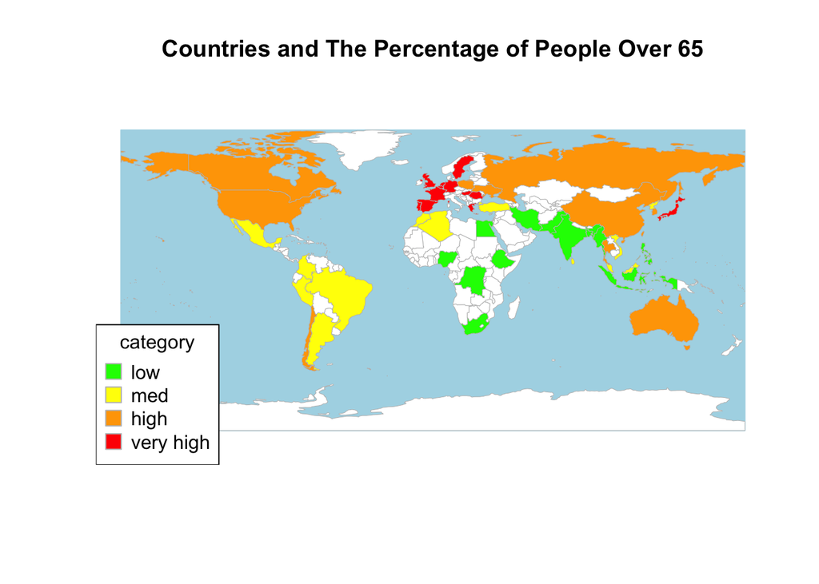

```
## 203 codes from your data successfully matched countries in the map
## 64 codes from your data failed to match with a country code in the map
## 40 codes from the map weren't represented in your data
```

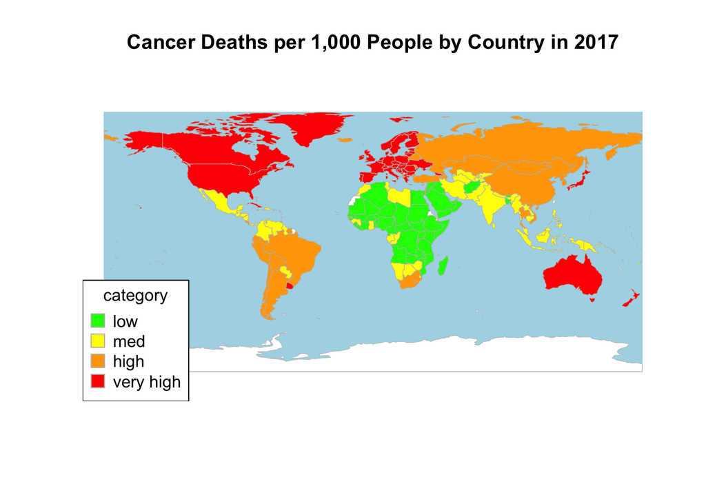

In fact, there has been an article written about this phenomenon [Why you’re more likely to die of cancer in Europe than America](https://www.politico.eu/article/cancer-europe-america-comparison/). In summary, aging population is listed as one of the major predictors for cancer deaths, along with variables such as smoking and high medical costs.  
This also implies that examining the age of the country’s population proves to be a better measure than using urban growth as it can predict with more accuracy on the world level, i.e when we average out the numbers) whereas urban growth is more picky in terms of what *specific type of cancer* it is used to predict.

# Conclusion